# Knowledge Discovery and Data Visualization Exam

Michael Hornicek

2022-12-22

```r
knitr::opts_chunk$set(cache =TRUE)
```

## Question 1

Open data set and generate random subset of 480 observations

```r
# read file
housing <- read.csv(
  file="./housing.csv",
  sep = ";",
  header = FALSE,
  col.names = c("CRIM", "ZN", "INDUS", "CHAS", "NOX", "RM", "AGE", "DIS", "RAD", "TAX", "PTRATIO", "B", "LSTAT", "MEDV")
)

# get random subset
set.seed(0)
index <- sample(1:nrow(housing), 480)
housing_subset <- housing[index, ]
summary(housing_subset)
```

```
##       CRIM                ZN             INDUS             CHAS
##  Min.   : 0.00632   Min.   :  0.00   Min.   : 0.460   Min.   :0.00000
##  1st Qu.: 0.08005   1st Qu.:  0.00   1st Qu.: 5.130   1st Qu.:0.00000
##  Median : 0.24751   Median :  0.00   Median : 9.125   Median :0.00000
##  Mean   : 3.68754   Mean   : 11.44   Mean   :11.056   Mean   :0.06875
##  3rd Qu.: 3.69407   3rd Qu.: 12.50   3rd Qu.:18.100   3rd Qu.:0.00000
##  Max.   :88.97620   Max.   :100.00   Max.   :27.740   Max.   :1.00000
##       NOX               RM             AGE              DIS
##  Min.   :0.3850   Min.   :3.561   Min.   :  2.90   Min.   : 1.130
##  1st Qu.:0.4480   1st Qu.:5.885   1st Qu.: 44.23   1st Qu.: 2.103
##  Median :0.5380   Median :6.211   Median : 76.85   Median : 3.239
##  Mean   :0.5544   Mean   :6.288   Mean   : 68.21   Mean   : 3.820
##  3rd Qu.:0.6240   3rd Qu.:6.629   3rd Qu.: 94.10   3rd Qu.: 5.255
##  Max.   :0.8710   Max.   :8.780   Max.   :100.00   Max.   :12.127
##       RAD              TAX           PTRATIO            B
##  Min.   : 1.000   Min.   :187.0   Min.   :12.60   Min.   :  0.32
##  1st Qu.: 4.000   1st Qu.:279.0   1st Qu.:17.00   1st Qu.:375.47
##  Median : 5.000   Median :332.0   Median :19.10   Median :391.48
##  Mean   : 9.585   Mean   :408.5   Mean   :18.45   Mean   :356.29
##  3rd Qu.:24.000   3rd Qu.:666.0   3rd Qu.:20.20   3rd Qu.:396.21
##  Max.   :24.000   Max.   :711.0   Max.   :22.00   Max.   :396.90
##      LSTAT             MEDV
##  Min.   : 1.730   Min.   : 5.00
##  1st Qu.: 6.928   1st Qu.:16.80
##  Median :11.330   Median :21.20
##  Mean   :12.644   Mean   :22.56
##  3rd Qu.:16.790   3rd Qu.:25.00
##  Max.   :37.970   Max.   :50.00
```

## Question 2

### Pre-processing

To start pre-processing, first check if there are any missing values.

```r
# check for NA values
na_count <- sapply(housing_subset, function(value) sum(length(which(is.na(value)))))
na_count <- data.frame(na_count)
na_count
```

```
##         na_count
## CRIM           0
## ZN             0
## INDUS          0
## CHAS           0
## NOX            0
## RM             0
## AGE            0
## DIS            0
## RAD            0
## TAX            0
## PTRATIO        0
## B              0
## LSTAT          0
## MEDV           0
```

There are no missing values.

### Outliers

Next, let’s try to find outliers. In order to find outliers, and simultaneously gain some insight into the distribution of values, a histogram can be plotted. I plotted histograms for each variable using both the original values, and Z-score standardized values.

#### CRIM

The first variable, CRIM, which is the per capita crime rate of the town/sub-urb, does have outliers. These are the histograms, using both the raw values, and the z-score standardized values:

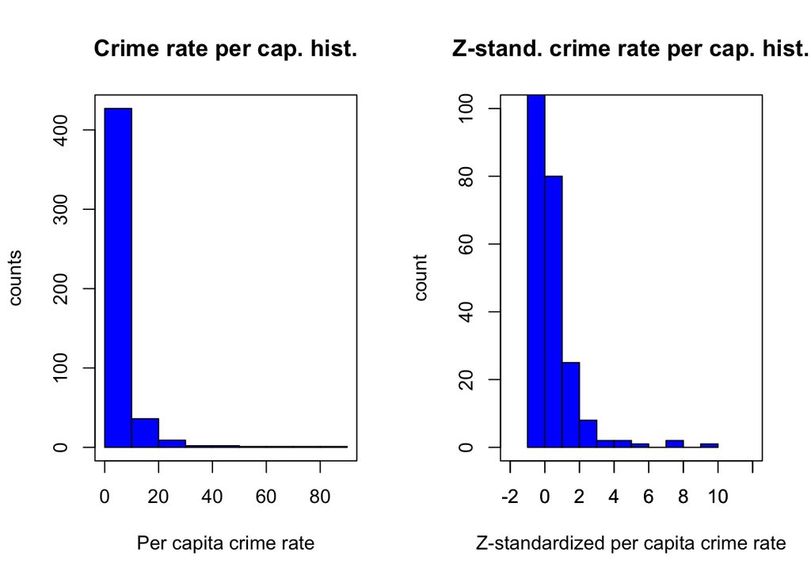

```r
# CRIME histogram
par(mfrow=c(1, 2))
hist(housing_subset$CRIM,
     col="blue",
     border="black",
     xlab="Per capita crime rate",
     ylab="counts",
     main="Crime rate per cap. hist.")
box(which="plot", lty="solid", col="black")

z_score_CRIM <- ((housing_subset$CRIM-mean(housing_subset$CRIM))/sd(housing_subset$CRIM))

hist(z_score_CRIM,
     breaks=10,
     col="blue",
     border="black",
     xlim = c(-2, 12),
     ylim = c(0, 100),
     xlab="Z-standardized per capita crime rate",
     ylab="count",
     main="Z-stand. crime rate per cap. hist.")
axis(side=1)
box(which="plot", lty="solid", col="black")
```

And if we want to have a look at the rows producing these outliers:

```r
housing_subset$CRIM_z <- ((housing_subset$CRIM-mean(housing_subset$CRIM))/sd(housing_subset$CRIM))


outliers <- housing_subset[housing_subset$CRIM_z > 3, ]
outliers
```

```
##        CRIM ZN INDUS CHAS   NOX    RM   AGE    DIS RAD TAX PTRATIO      B LSTAT
## 428 37.6619  0  18.1    0 0.679 6.202  78.7 1.8629  24 666    20.2  18.82 14.52
## 419 73.5341  0  18.1    0 0.679 5.957 100.0 1.8026  24 666    20.2  16.45 20.62
## 406 67.9208  0  18.1    0 0.693 5.683 100.0 1.4254  24 666    20.2 384.97 22.98
## 415 45.7461  0  18.1    0 0.693 4.519 100.0 1.6582  24 666    20.2  88.27 36.98
## 411 51.1358  0  18.1    0 0.597 5.757 100.0 1.4130  24 666    20.2   2.60 10.11
## 381 88.9762  0  18.1    0 0.671 6.968  91.9 1.4165  24 666    20.2 396.90 17.21
## 405 41.5292  0  18.1    0 0.693 5.531  85.4 1.6074  24 666    20.2 329.46 27.38
## 399 38.3518  0  18.1    0 0.693 5.453 100.0 1.4896  24 666    20.2 396.90 30.59
##     MEDV   CRIM_z
## 428 10.9 3.876408
## 419  8.8 7.969356
## 406  5.0 7.328890
## 415  7.0 4.798800
## 411 15.0 5.413754
## 381 10.4 9.731270
## 405  8.5 4.317660
## 399  5.0 3.955125
```

```r
nrow(outliers)
```

```
## [1] 8
```

And for a summary of the z-score for the CRIM variable:

```r
summary(housing_subset$CRIM_z)
```

```
##      Min.   1st Qu.    Median      Mean   3rd Qu.      Max.
## -0.420020 -0.411607 -0.392501  0.000000  0.000745  9.731270
```

There are values with extremely high z-scores, considering that an outlier is considered to be any variable with a z-score greater than 3 (or less than -3), and here we have a value of 9.73, and two more values of 7.969 and 7.329. However, I don’t know enough about the meaning of the CRIM variable (for example what its units are), to be able to say whether these values are so extreme that they must not be correct, or whether it is possible that they are correct.

#### ZN

The ZN variable, which is the proportion of residental land zoned for lots over 25000 sq ft also has outliers:

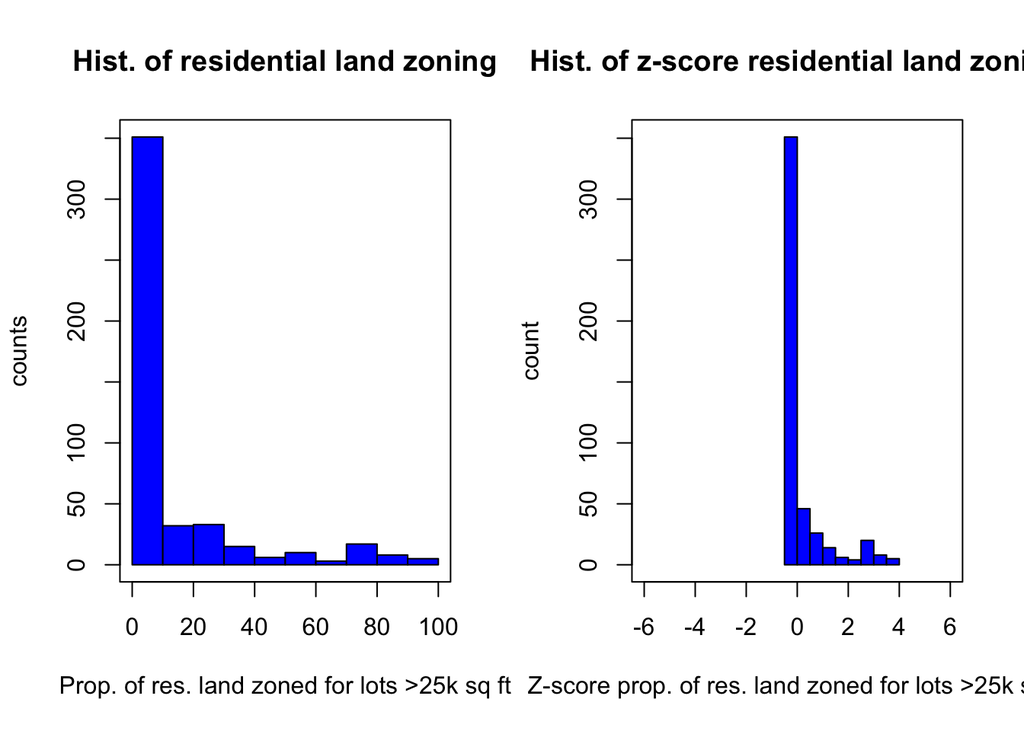

```r
par(mfrow=c(1, 2))
hist(housing_subset$ZN,
     col="blue",
     border="black",
     xlab="Prop. of res. land zoned for lots >25k sq ft",
     ylab="counts",
     main="Hist. of residential land zoning")
box(which="plot", lty="solid", col="black")

housing_subset$ZN_z <- ((housing_subset$ZN-mean(housing_subset$ZN))/sd(housing_subset$ZN))

hist(housing_subset$ZN_z,
     breaks=10,
     col="blue",
     border="black",
     xlim = c(-6, 6),
     xlab="Z-score prop. of res. land zoned for lots >25k sq ft",
     ylab="count",
     main="Hist. of z-score residential land zoning")
box(which="plot", lty="solid", col="black")
```

These are the records:

```r
housing_subset[housing_subset$ZN_z > 3, ]
```

```
##        CRIM    ZN INDUS CHAS    NOX    RM  AGE     DIS RAD TAX PTRATIO      B
## 285 0.00906  90.0  2.97    0 0.4000 7.088 20.8  7.3073   1 285    15.3 394.72
## 204 0.03510  95.0  2.68    0 0.4161 7.853 33.2  5.1180   4 224    14.7 392.78
## 284 0.01501  90.0  1.21    1 0.4010 7.923 24.8  5.8850   1 198    13.6 395.52
## 202 0.03445  82.5  2.03    0 0.4150 6.162 38.4  6.2700   2 348    14.7 393.77
## 56  0.01311  90.0  1.22    0 0.4030 7.249 21.9  8.6966   5 226    17.9 395.93
## 201 0.01778  95.0  1.47    0 0.4030 7.135 13.9  7.6534   3 402    17.0 384.30
## 203 0.02177  82.5  2.03    0 0.4150 7.610 15.7  6.2700   2 348    14.7 395.38
## 257 0.01538  90.0  3.75    0 0.3940 7.454 34.2  6.3361   3 244    15.9 386.34
## 58  0.01432 100.0  1.32    0 0.4110 6.816 40.5  8.3248   5 256    15.1 392.90
## 200 0.03150  95.0  1.47    0 0.4030 6.975 15.3  7.6534   3 402    17.0 396.90
## 354 0.01709  90.0  2.02    0 0.4100 6.728 36.1 12.1265   5 187    17.0 384.46
## 348 0.01870  85.0  4.15    0 0.4290 6.516 27.7  8.5353   4 351    17.9 392.43
## 205 0.02009  95.0  2.68    0 0.4161 8.034 31.9  5.1180   4 224    14.7 390.55
##     LSTAT MEDV     CRIM_z     ZN_z
## 285  7.85 32.2 -0.4197073 3.369561
## 204  3.81 48.5 -0.4167361 3.584012
## 284  3.16 50.0 -0.4190284 3.369561
## 202  7.43 24.1 -0.4168103 3.047884
## 56   4.81 35.4 -0.4192452 3.369561
## 201  4.45 32.9 -0.4187123 3.584012
## 203  3.11 42.3 -0.4182571 3.047884
## 257  3.11 44.0 -0.4189862 3.369561
## 58   3.95 31.6 -0.4191071 3.798463
## 200  4.56 34.9 -0.4171469 3.584012
## 354  4.50 30.1 -0.4187911 3.369561
## 348  6.36 23.1 -0.4186074 3.155110
## 205  2.88 50.0 -0.4184488 3.584012
```

```r
nrow(housing_subset[housing_subset$ZN_z > 3, ])
```

```
## [1] 13
```

While there are more outliers here compared to CRIM (13 here vs 8 for CRIM), their values are nowhere near as extreme, with the most extreme outlier having a z-score of 3.80.

#### RM

The next variable containing outliers (as classified using z-score) is RM, which is the average number of rooms per house.

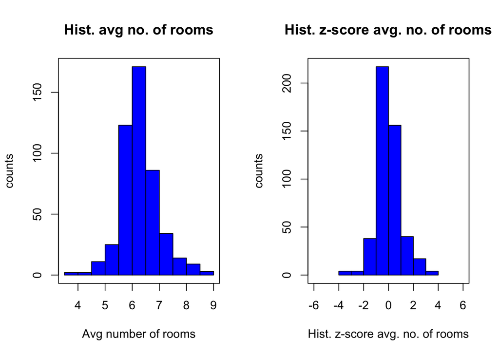

```r
par(mfrow=c(1, 2))
hist(housing_subset$RM,
     col="blue",
     border="black",
     xlab="Avg number of rooms",
     ylab="counts",
     main="Hist. avg no. of rooms")
box(which="plot", lty="solid", col="black")

housing_subset$RM_z <- ((housing_subset$RM-mean(housing_subset$RM))/sd(housing_subset$RM))

hist(housing_subset$RM_z,
     breaks=10,
     col="blue",
     border="black",
     xlim = c(-6, 6),
     xlab="Hist. z-score avg. no. of rooms",
     ylab="counts",
     main="Hist. z-score avg. no. of rooms")
box(which="plot", lty="solid", col="black")
```

There are 8 outliers, which is a similar amount to other quantities. Their values are not very extreme either, with the greatest outlier having a z-score of -3.88.

```r
outliers <- housing_subset[housing_subset$RM_z > 3 | housing_subset$RM_z < -3, ]

nrow(outliers)
```

```
## [1] 8
```

```r
summary(housing_subset$RM_z)
```

```
##    Min. 1st Qu.  Median    Mean 3rd Qu.    Max.
## -3.8849 -0.5745 -0.1097  0.0000  0.4861  3.5501
```

#### DIS

The next variable with outliers is the DIS variable, representing the weighted distances to 5 Boston employment centers.

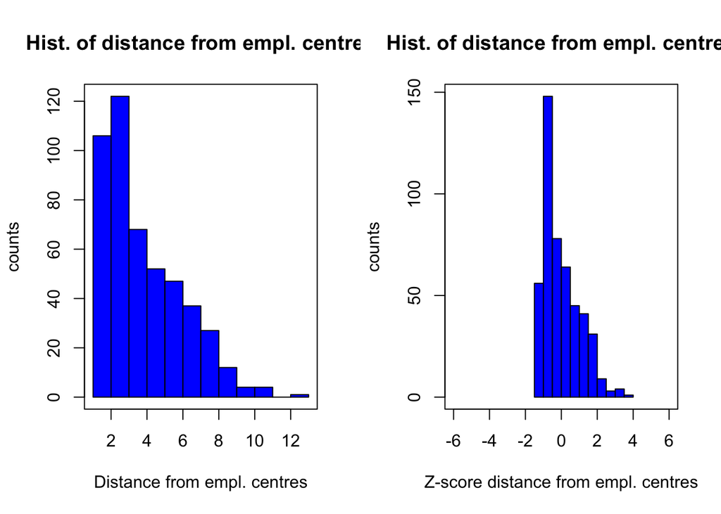

```r
par(mfrow=c(1, 2))
hist(housing_subset$DIS,
     col="blue",
     border="black",
     xlab="Distance from empl. centres",
     ylab="counts",
     main="Hist. of distance from empl. centres")
box(which="plot", lty="solid", col="black")

housing_subset$DIS_z <- ((housing_subset$DIS-mean(housing_subset$DIS))/sd(housing_subset$DIS))

hist(housing_subset$DIS_z,
     breaks=10,
     col="blue",
     border="black",
     xlim = c(-6, 6),
     xlab="Z-score distance from empl. centres",
     ylab="counts",
     main="Hist. of distance from empl. centres")
box(which="plot", lty="solid", col="black")
```

The records:

```r
housing_subset[housing_subset$DIS_z > 3, ]
```

```
##        CRIM ZN INDUS CHAS   NOX    RM  AGE     DIS RAD TAX PTRATIO      B LSTAT
## 355 0.04301 80  1.91    0 0.413 5.663 21.9 10.5857   4 334    22.0 382.80  8.05
## 352 0.07950 60  1.69    0 0.411 6.579 35.9 10.7103   4 411    18.3 370.78  5.49
## 353 0.07244 60  1.69    0 0.411 5.884 18.5 10.7103   4 411    18.3 392.33  7.79
## 356 0.10659 80  1.91    0 0.413 5.936 19.5 10.5857   4 334    22.0 376.04  5.57
## 354 0.01709 90  2.02    0 0.410 6.728 36.1 12.1265   5 187    17.0 384.46  4.50
##     MEDV     CRIM_z     ZN_z       RM_z    DIS_z
## 355 18.2 -0.4158336 2.940659 -0.8903728 3.186826
## 352 24.1 -0.4116702 2.082855  0.4145532 3.245519
## 353 18.6 -0.4124757 2.082855 -0.5755380 3.245519
## 356 20.6 -0.4085793 2.940659 -0.5014593 3.186826
## 354 30.1 -0.4187911 3.369561  0.6268174 3.912627
```

```r
nrow(housing_subset[housing_subset$DIS_z > 3, ])
```

```
## [1] 5
```

```r
summary(housing_subset$DIS_z)
```

```
##    Min. 1st Qu.  Median    Mean 3rd Qu.    Max.
## -1.2675 -0.8091 -0.2738  0.0000  0.6759  3.9126
```

Compared to other variables, DIS has 5 outliers, which is relatively few. Their values are also not particularly extreme, with the greatest outlier having a z-score of 3.91.

#### B

The next variable with outliers is the B variable, which is linked to the proportion of the black population in the town.

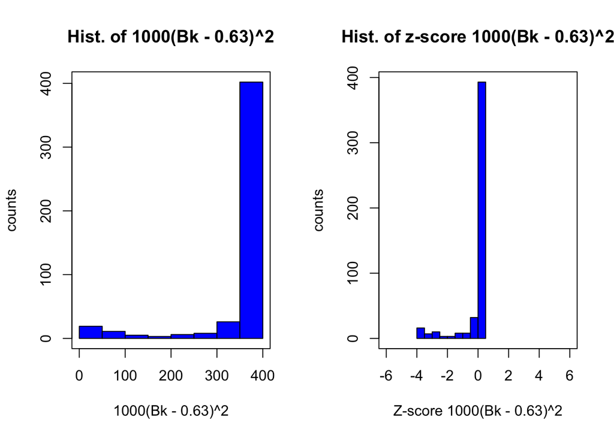

```r
par(mfrow=c(1, 2))
hist(housing_subset$B,
     col="blue",
     border="black",
     xlab="1000(Bk - 0.63)^2",
     ylab="counts",
     main="Hist. of 1000(Bk - 0.63)^2")
box(which="plot", lty="solid", col="black")

housing_subset$B_z <- ((housing_subset$B-mean(housing_subset$B))/sd(housing_subset$B))

hist(housing_subset$B_z,
     breaks=10,
     col="blue",
     border="black",
     xlim = c(-6, 6),
     xlab="Z-score 1000(Bk - 0.63)^2",
     ylab="counts",
     main="Hist. of z-score 1000(Bk - 0.63)^2")
box(which="plot", lty="solid", col="black")
```

These are the records:

```r
housing_subset[housing_subset$B_z < -3, ]
```

```
##         CRIM ZN INDUS CHAS   NOX    RM   AGE    DIS RAD TAX PTRATIO     B LSTAT
## 438 15.17720  0 18.10    0 0.740 6.152 100.0 1.9142  24 666    20.2  9.32 26.45
## 428 37.66190  0 18.10    0 0.679 6.202  78.7 1.8629  24 666    20.2 18.82 14.52
## 419 73.53410  0 18.10    0 0.679 5.957 100.0 1.8026  24 666    20.2 16.45 20.62
## 412 14.05070  0 18.10    0 0.597 6.657 100.0 1.5275  24 666    20.2 35.05 21.22
## 103  0.22876  0  8.56    0 0.520 6.405  85.4 2.7147   5 384    20.9 70.80 10.63
## 430  9.33889  0 18.10    0 0.679 6.380  95.6 1.9682  24 666    20.2 60.72 24.08
## 427 12.24720  0 18.10    0 0.584 5.837  59.7 1.9976  24 666    20.2 24.65 15.69
## 467  3.77498  0 18.10    0 0.655 5.952  84.7 2.8715  24 666    20.2 22.01 17.15
## 457  4.66883  0 18.10    0 0.713 5.976  87.9 2.5806  24 666    20.2 10.48 19.01
## 458  8.20058  0 18.10    0 0.713 5.936  80.3 2.7792  24 666    20.2  3.50 16.94
## 446 10.67180  0 18.10    0 0.740 6.459  94.8 1.9879  24 666    20.2 43.06 23.98
## 411 51.13580  0 18.10    0 0.597 5.757 100.0 1.4130  24 666    20.2  2.60 10.11
## 451  6.71772  0 18.10    0 0.713 6.749  92.6 2.3236  24 666    20.2  0.32 17.44
## 426 15.86030  0 18.10    0 0.679 5.896  95.4 1.9096  24 666    20.2  7.68 24.39
```

[output cut: 33 more lines]

```r
nrow(housing_subset[housing_subset$B_z < -3, ])
```

```
## [1] 23
```

```r
summary(housing_subset$B_z)
```

```
##    Min. 1st Qu.  Median    Mean 3rd Qu.    Max.
## -3.8701  0.2086  0.3826  0.0000  0.4341  0.4416
```

Unlike for other variables, this one has outliers mainly to the left of the center. There are also relatively many, at 23. Though their values are not very extreme, with the most extreme having a z-score of -3.87.

#### LSTAT

The next variable with outliers is the LSTAT variable, representing the % of lower status of the population.

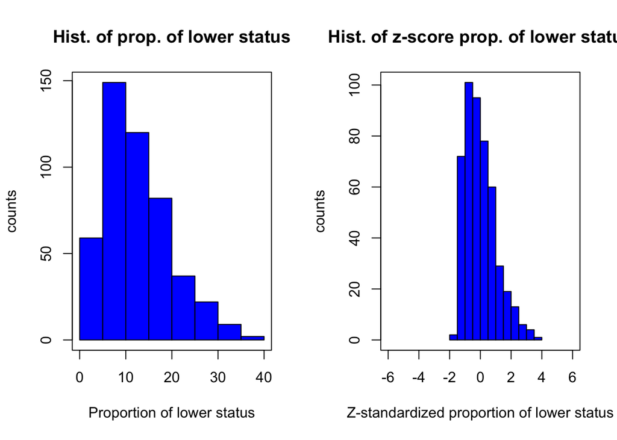

```r
# LSTAT histogram
par(mfrow=c(1, 2))
hist(housing_subset$LSTAT,
     col="blue",
     border="black",
     xlab="Proportion of lower status",
     ylab="counts",
     main="Hist. of prop. of lower status")
box(which="plot", lty="solid", col="black")

housing_subset$LSTAT_z <- ((housing_subset$LSTAT-mean(housing_subset$LSTAT))/sd(housing_subset$LSTAT))

hist(housing_subset$LSTAT_z,
     breaks=10,
     col="blue",
     border="black",
     xlim = c(-6, 6),
     xlab="Z-standardized proportion of lower status",
     ylab="counts",
     main="Hist. of z-score prop. of lower status")
box(which="plot", lty="solid", col="black")
```

These are the records:

```r
housing_subset[housing_subset$LSTAT_z > 3, ]
```

```
##         CRIM ZN INDUS CHAS   NOX    RM AGE    DIS RAD TAX PTRATIO      B LSTAT
## 375 18.49820  0 18.10    0 0.668 4.138 100 1.1370  24 666    20.2 396.90 37.97
## 415 45.74610  0 18.10    0 0.693 4.519 100 1.6582  24 666    20.2  88.27 36.98
## 413 18.81100  0 18.10    0 0.597 4.628 100 1.5539  24 666    20.2  28.79 34.37
## 374 11.10810  0 18.10    0 0.668 4.906 100 1.1742  24 666    20.2 396.90 34.77
## 142  1.62864  0 21.89    0 0.624 5.019 100 1.4394   4 437    21.2 396.90 34.41
##     MEDV     CRIM_z       ZN_z      RM_z     DIS_z        B_z  LSTAT_z
## 375 13.8  1.6898675 -0.4905566 -3.062875 -1.264033  0.4415516 3.544377
## 415  7.0  4.7987997 -0.4905566 -2.520106 -1.018519 -2.9138738 3.405827
## 413 17.9  1.7255574 -0.4905566 -2.364825 -1.067650 -3.5605404 3.040559
## 374 13.8  0.8466715 -0.4905566 -1.968789 -1.246510  0.4415516 3.096539
## 142 14.4 -0.2349163 -0.4905566 -1.807810 -1.121586  0.4415516 3.046157
```

```r
nrow(housing_subset[housing_subset$LSTAT_z > 3, ])
```

```
## [1] 5
```

```r
summary(housing_subset$LSTAT_z)
```

```
##    Min. 1st Qu.  Median    Mean 3rd Qu.    Max.
## -1.5274 -0.8000 -0.1839  0.0000  0.5803  3.5444
```

This variable also has relatively few outliers with not very extreme, with the most extreme having a z-score of 3.54.

### Correlations analysis of numeric variables

Below are correlation coefficients between all the numeric variables and the target variable:

```r
# Collect variables of interest
corrdata <- cbind(housing_subset$CRIM,
                  housing_subset$ZN,
                  housing_subset$INDUS,
                  housing_subset$NOX,
                  housing_subset$RM,
                  housing_subset$AGE,
                  housing_subset$DIS,
                  housing_subset$RAD,
                  housing_subset$TAX,
                  housing_subset$PTRATIO,
                  housing_subset$B,
                  housing_subset$LSTAT,
                  housing_subset$MEDV)
# Declare the matrix
corrpvalues <- matrix(rep(0, 169),
                      ncol = 13)
# Fill the matrix with correlations
for (i in 1:12) {
  for (j in (i+1):13) {
    corrpvalues[i,j] <- corrpvalues[j,i] <-
      round(cor.test(corrdata[,i],
                     corrdata[,j])$p.value,
            4)
  }
}

correlations <- round(cor(corrdata), 4)
colnames(correlations) <- c("CRIM", "ZN", "INDUS", "NOX", "RM", "AGE", "DIS", "RAD", "TAX", "PTRATIO", "B", "LSTAT", "MEDV")
rownames(correlations) <- c("CRIM", "ZN", "INDUS", "NOX", "RM", "AGE", "DIS", "RAD", "TAX", "PTRATIO", "B", "LSTAT", "MEDV")
correlations
```

```
##            CRIM      ZN   INDUS     NOX      RM     AGE     DIS     RAD     TAX
## CRIM     1.0000 -0.2023  0.4150  0.4191 -0.2117  0.3594 -0.3827  0.6246  0.5845
## ZN      -0.2023  1.0000 -0.5355 -0.5155  0.3127 -0.5658  0.6620 -0.3131 -0.3147
## INDUS    0.4150 -0.5355  1.0000  0.7687 -0.3791  0.6497 -0.7099  0.6098  0.7264
## NOX      0.4191 -0.5155  0.7687  1.0000 -0.2975  0.7336 -0.7697  0.6097  0.6663
## RM      -0.2117  0.3127 -0.3791 -0.2975  1.0000 -0.2423  0.2009 -0.2026 -0.2774
## AGE      0.3594 -0.5658  0.6497  0.7336 -0.2423  1.0000 -0.7449  0.4702  0.5185
## DIS     -0.3827  0.6620 -0.7099 -0.7697  0.2009 -0.7449  1.0000 -0.5003 -0.5397
## RAD      0.6246 -0.3131  0.6098  0.6097 -0.2026  0.4702 -0.5003  1.0000  0.9147
## TAX      0.5845 -0.3147  0.7264  0.6663 -0.2774  0.5185 -0.5397  0.9147  1.0000
## PTRATIO  0.2905 -0.3985  0.3744  0.1841 -0.3482  0.2699 -0.2329  0.4670  0.4574
## B       -0.3827  0.1771 -0.3617 -0.3862  0.1194 -0.2834  0.2938 -0.4421 -0.4399
## LSTAT    0.4538 -0.4100  0.6024  0.5913 -0.6038  0.6072 -0.4955  0.4887  0.5396
## MEDV    -0.3868  0.3575 -0.4744 -0.4243  0.6865 -0.3789  0.2453 -0.3799 -0.4584
##         PTRATIO       B   LSTAT    MEDV
## CRIM     0.2905 -0.3827  0.4538 -0.3868
## ZN      -0.3985  0.1771 -0.4100  0.3575
## INDUS    0.3744 -0.3617  0.6024 -0.4744
## NOX      0.1841 -0.3862  0.5913 -0.4243
## RM      -0.3482  0.1194 -0.6038  0.6865
## AGE      0.2699 -0.2834  0.6072 -0.3789
## DIS     -0.2329  0.2938 -0.4955  0.2453
## RAD      0.4670 -0.4421  0.4887 -0.3799
## TAX      0.4574 -0.4399  0.5396 -0.4584
## PTRATIO  1.0000 -0.1762  0.3670 -0.5040
## B       -0.1762  1.0000 -0.3692  0.3304
## LSTAT    0.3670 -0.3692  1.0000 -0.7332
## MEDV    -0.5040  0.3304 -0.7332  1.0000
```

### Frequency tables for categorical variables

```r
# bin house values - equal binning

xdata <- housing_subset$MEDV
n <- length(xdata)
nbins <- 4
whichbin <- c(rep(0, n))
range_xdata <- max(xdata) - min(xdata) + 1
binwidth <- range_xdata/nbins
for (i in 1:nbins) {
  for (j in 1:n) {
    if((i-1)*binwidth < xdata[j] &&
       xdata[j] <= (i)*binwidth)
      whichbin[j] <- i
  }
}

housing_subset$MEDV_bin <- whichbin

table(housing_subset$MEDV_bin, housing_subset$CHAS, dnn=c("MEDV bin", "CHAS"))
```

```
##         CHAS
## MEDV bin   0   1
##        0  14   6
##        1  34   0
##        2 251  15
##        3 120  10
##        4  28   2
```

### Analysis / interesting relationships

#### Crime and median house value

In terms of interesting relationships between the target variable and other variables, in my opinion, the relationships where there was a low correlation were more interesting. The strongest correlations occurred for variables which I would expect to be strongly correlated, such as the average number of rooms per dwelling and the percentage of lower status of the population. It seems quite obvious that those would be correlated with the median house value.

On the other hand, I was surprised that crime had one of the lowest correlation coefficients (-0.3868). This is what the scatter plot looks like:

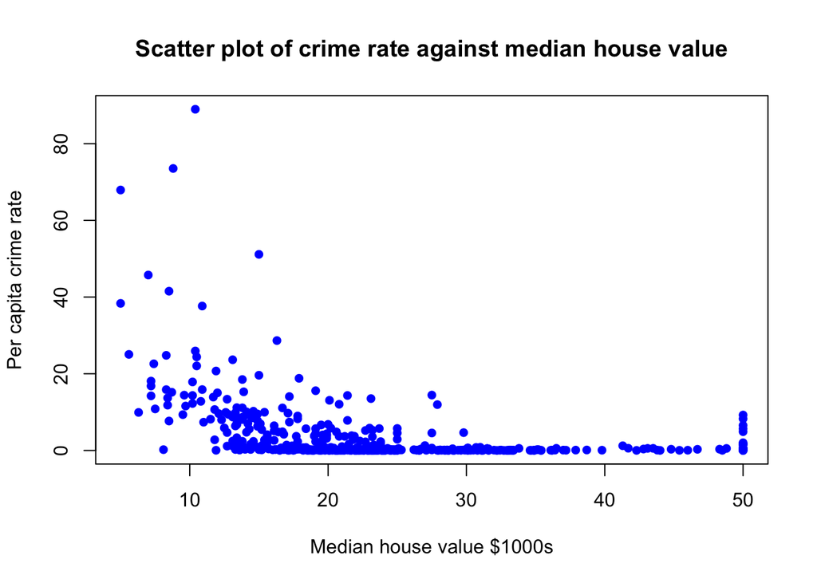

```r
plot(housing_subset$MEDV, housing_subset$CRIM,
     xlab = "Median house value $1000s",
     ylab = "Per capita crime rate",
     main = "Scatter plot of crime rate against median house value",
     type = "p",
     pch = 16,
     col = "blue")
```

For lower median house values (circa below 30k), the scatter plot looks like what I would expect, as the median house value increases, the crime rate decreases. After 30k, the crime rate remains stable, which also makes sense, because it is quite close to 0, and it can’t go lower. Unexpectedly, at 50k, there are some suburbs with higher than expected crime rates.

```r
most_expensive <- housing_subset[housing_subset$MEDV > 49, ]
most_expensive_sorted <- most_expensive[order(most_expensive$CRIM), ]
most_expensive_sorted
```

```
##        CRIM ZN INDUS CHAS    NOX    RM   AGE    DIS RAD TAX PTRATIO      B
## 196 0.01381 80  0.46    0 0.4220 7.875  32.0 5.6484   4 255    14.4 394.23
## 284 0.01501 90  1.21    1 0.4010 7.923  24.8 5.8850   1 198    13.6 395.52
## 205 0.02009 95  2.68    0 0.4161 8.034  31.9 5.1180   4 224    14.7 390.55
## 187 0.05602  0  2.46    0 0.4880 7.831  53.6 3.1992   3 193    17.8 392.63
## 226 0.52693  0  6.20    0 0.5040 8.725  83.0 2.8944   8 307    17.4 382.00
## 268 0.57834 20  3.97    0 0.5750 8.297  67.0 2.4216   5 264    13.0 384.54
## 258 0.61154 20  3.97    0 0.6470 8.704  86.9 1.8010   5 264    13.0 389.70
## 162 1.46336  0 19.58    0 0.6050 7.489  90.8 1.9709   5 403    14.7 374.43
## 164 1.51902  0 19.58    1 0.6050 8.375  93.9 2.1620   5 403    14.7 388.45
## 163 1.83377  0 19.58    1 0.6050 7.802  98.2 2.0407   5 403    14.7 389.61
## 167 2.01019  0 19.58    0 0.6050 7.929  96.2 2.0459   5 403    14.7 369.30
## 369 4.89822  0 18.10    0 0.6310 4.970 100.0 1.3325  24 666    20.2 375.52
## 370 5.66998  0 18.10    1 0.6310 6.683  96.8 1.3567  24 666    20.2 375.33
## 371 6.53876  0 18.10    1 0.6310 7.016  97.5 1.2024  24 666    20.2 392.05
```

[output cut: 36 more lines]

When we look at the data for those houses, sorted by crime, a trend emerges. For these most expensive houses, there seems to be a very strong correlation between CRIM and DIS. The neighborhoods which have expensive houses and relatively higher crime, they very low distance to employment centres. This kind of makes sense - those properties tend to be expensive, and the people living there might be willing to accept higher levels of crime in exchange for being very close to the center.

```r
fit <- lm(most_expensive$CRIM ~ most_expensive$DIS)
summary(fit)
```

```
##
## Call:
## lm(formula = most_expensive$CRIM ~ most_expensive$DIS)
##
## Residuals:
##     Min      1Q  Median      3Q     Max
## -3.1469 -1.7775 -0.4545  1.5056  4.6246
##
## Coefficients:
##                    Estimate Std. Error t value Pr(>|t|)
## (Intercept)          6.1788     1.1642   5.307 0.000111 ***
## most_expensive$DIS  -1.3439     0.3866  -3.476 0.003709 **
## ---
## Signif. codes:  0 '***' 0.001 '**' 0.01 '*' 0.05 '.' 0.1 ' ' 1
##
## Residual standard error: 2.385 on 14 degrees of freedom
## Multiple R-squared:  0.4632, Adjusted R-squared:  0.4249
## F-statistic: 12.08 on 1 and 14 DF,  p-value: 0.003709
```

```r
fit <- lm(housing_subset$CRIM ~ housing_subset$DIS)
summary(fit)
```

```
##
## Call:
## lm(formula = housing_subset$CRIM ~ housing_subset$DIS)
##
## Residuals:
##    Min     1Q Median     3Q    Max
## -6.886 -4.235 -1.485  1.499 81.491
##
## Coefficients:
##                    Estimate Std. Error t value Pr(>|t|)
## (Intercept)          9.7237     0.7623  12.756   <2e-16 ***
## housing_subset$DIS  -1.5800     0.1745  -9.057   <2e-16 ***
## ---
## Signif. codes:  0 '***' 0.001 '**' 0.01 '*' 0.05 '.' 0.1 ' ' 1
##
## Residual standard error: 8.106 on 478 degrees of freedom
## Multiple R-squared:  0.1465, Adjusted R-squared:  0.1447
## F-statistic: 82.02 on 1 and 478 DF,  p-value: < 2.2e-16
```

#### Distance and median house value

Another interesting relationship, kind of related to the previous one, is between the distance to employment centres and median house values. This one actually has the lowest correlation to median house values, which I was also surprised by. Here is the scatter plot:

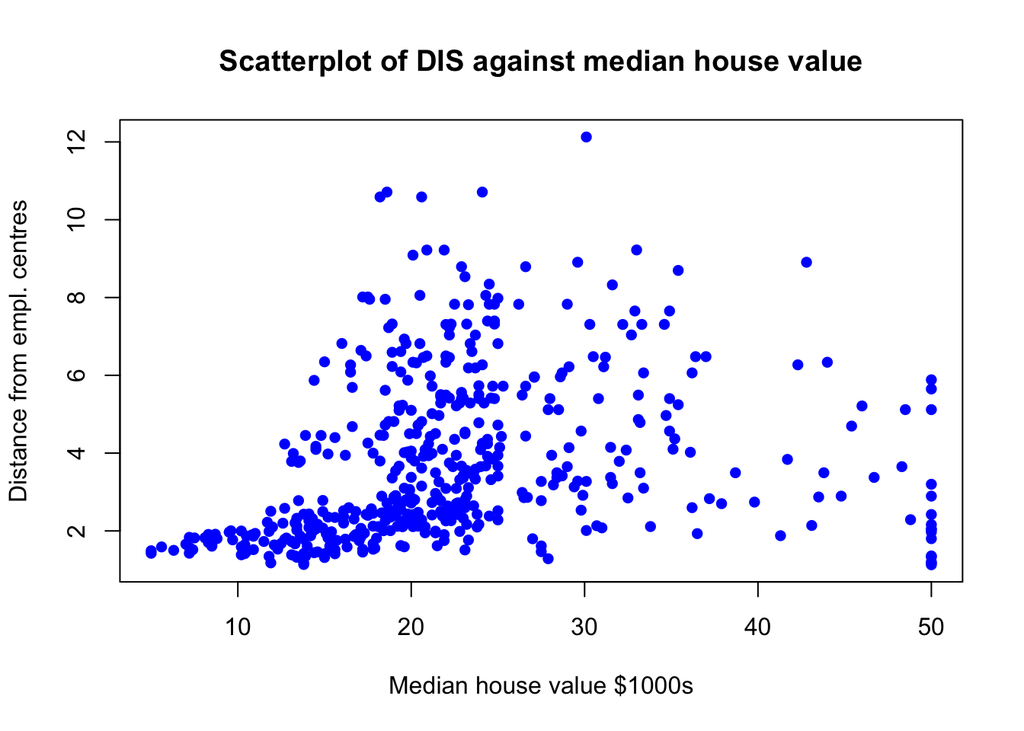

```r
plot(housing_subset$MEDV, housing_subset$DIS,
     xlab = "Median house value $1000s",
     ylab = "Distance from empl. centres",
     main = "Scatterplot of DIS against median house value",
     type = "p",
     pch = 16,
     col = "blue")
```

Describing the trend in the scatter plot has some similarities with the crime rate trend. Up until a median house value of about 30k, there is a relatively strong correlation between distance from employment centres and the median house value. This is actually opposite of what I expected, I would expect prices to decreases as one gets further away from the center. And then after the price surpasses about 30k, the trend kind of reverses - as price increases, distance decreases.

This suggests that sub-urban areas, which are further away from the centre ten to be quite middle class (since houses of average value tend to be found there). On the other hand, areas close to the center of town seem to be either very rich, or very poor.

#### Nitrous oxide pollution and median house value

The relationship between nitric oxides and median house value also seems to be in line with the hypothesis that the sub-urban areas, further away from the center tend to be middle class and the center has relatively poor and relatively rich people living there. Again, the NOX variable has a relatively low correlation to the median house value. Here is the scatter plot:

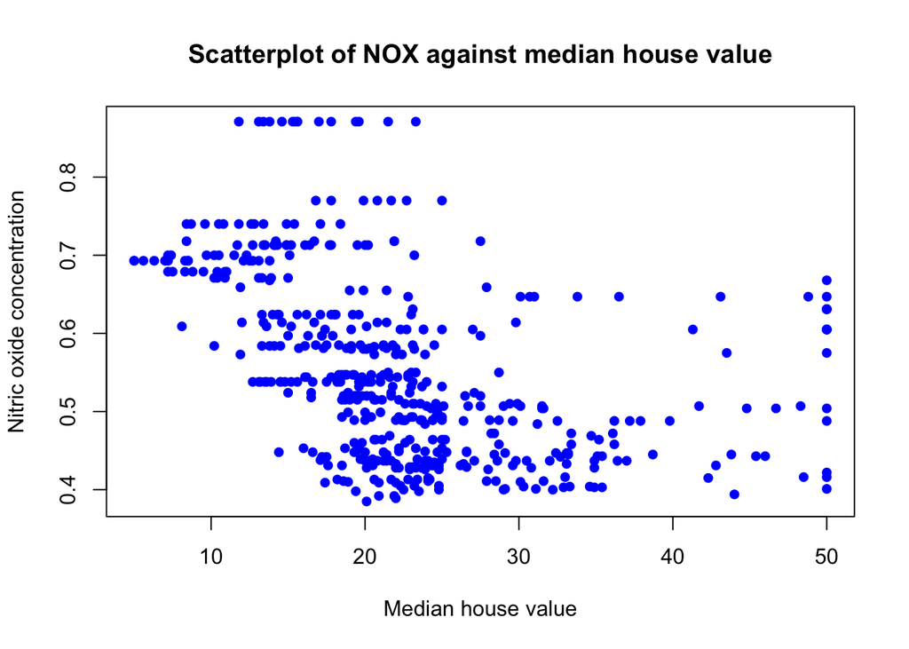

```r
plot(housing_subset$MEDV, housing_subset$NOX,
     xlab = "Median house value",
     ylab = "Nitric oxide concentration",
     main = "Scatterplot of NOX against median house value",
     type = "p",
     pch = 16,
     col = "blue")
```

Like with crime, the scatter has kind of a U shape, where the neighborhoods with the lowest house values and those with the highest house values both tned to have relatively high concentration of polluting nitrous oxides. On the other hand, the more average neighborhoods (in terms of their median house value) tend to have lower nitrous oxide pollution.

### Question 3

#### Partition into training and testing

```r
housing_subset$part <- runif(nrow(housing_subset), min=0, max=1)
training <- housing_subset[housing_subset$part <=0.75, ]
testing <- housing_subset[housing_subset$part > 0.75, ]
```

#### Validate partition

```r
testing_sample_mean <- mean(testing$MEDV)
training_sample_mean <- mean(training$MEDV)

testing_sample_mean; training_sample_mean
```

```
## [1] 22.40593
```

```
## [1] 22.6163
```

```r
testing_sample_size <- nrow(testing)
training_sample_size <- nrow(training)

testing_sample_sd <- sd(testing$MEDV)
training_sample_sd <- sd(training$MEDV)

dfs <- min(testing_sample_size, training_sample_size)

t_data <- (testing_sample_mean - training_sample_mean) / sqrt((training_sample_sd^2 / training_sample_size) + (testing_sample_mean^2 / testing_sample_size))

p_value <- 2*pt(t_data, df=dfs, lower.tail=FALSE)

t_data;p_value
```

```
## [1] -0.09953609
```

```
## [1] 1.079118
```

##### KNN

```r
library(class)

testing$MEDV_bin_pred_knn <- knn(training, testing, cl=training$MEDV_bin, k=5, prob=TRUE)

head(testing)
```

```
##         CRIM ZN INDUS CHAS   NOX    RM  AGE    DIS RAD TAX PTRATIO      B LSTAT
## 167  2.01019  0 19.58    0 0.605 7.929 96.2 2.0459   5 403    14.7 369.30  3.70
## 418 25.94060  0 18.10    0 0.679 5.304 89.1 1.6475  24 666    20.2 127.36 26.64
## 85   0.05059  0  4.49    0 0.449 6.389 48.0 4.7794   3 247    18.5 396.90  9.62
## 277  0.10469 40  6.41    1 0.447 7.267 49.0 4.7872   4 254    17.6 389.25  6.05
## 37   0.09744  0  5.96    0 0.499 5.841 61.4 3.3779   5 279    19.2 377.56 11.41
## 366  4.55587  0 18.10    0 0.718 3.561 87.9 1.6132  24 666    20.2 354.70  7.12
##     MEDV      CRIM_z       ZN_z       RM_z      DIS_z         B_z    LSTAT_z
## 167 50.0 -0.19138223 -0.4905566  2.3377521 -0.8358908  0.14148436 -1.2516863
## 418 10.4  2.53903085 -0.4905566 -1.4018012 -1.0235592 -2.48888732  1.9587511
## 85  23.9 -0.41496877 -0.4905566  0.1438808  0.4517383  0.44155156 -0.4231863
## 277 33.2 -0.40879606  1.2250511  1.3946724  0.4554125  0.35838076 -0.9228054
## 37  20.0 -0.40962327 -0.4905566 -0.6367955 -0.2084454  0.23128708 -0.1726770
## 366 27.5  0.09907489 -0.4905566 -3.8848647 -1.0397164 -0.01724684 -0.7730596
##     MEDV_bin      part MEDV_bin_pred_knn
## 167        0 0.7681446                 0
## 418        1 0.8280750                 2
## 85         3 0.7914560                 2
## 277        3 0.7781813                 2
## 37         2 0.9193318                 2
## 366        3 0.8201716                 2
```

```r
cm = as.matrix(table(Actual = testing$MEDV_bin, Predicted = testing$MEDV_bin_pred_knn))

sum(diag(cm))/length(training$MEDV_bin)
```

```
## [1] 0.198895
```

##### CART

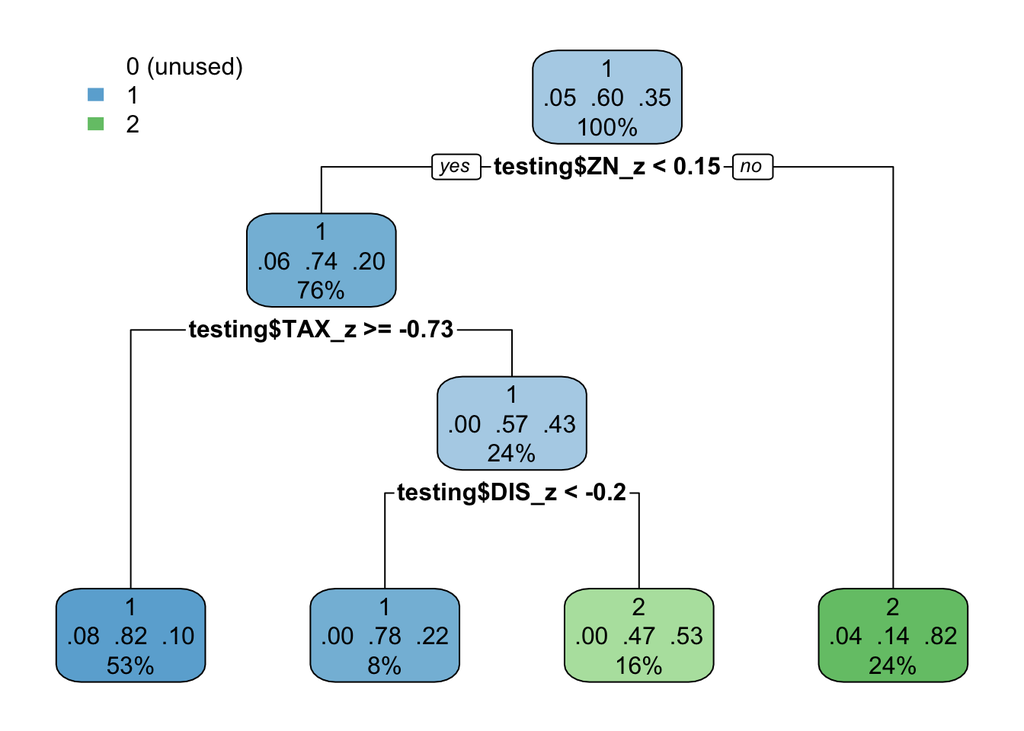

```r
library("rpart"); library("rpart.plot")

# normalize values

testing$INDUS_z <- ((testing$INDUS-mean(testing$INDUS))/sd(testing$INDUS))

testing$NOX_z <- ((testing$NOX-mean(testing$NOX))/sd(testing$NOX))

testing$AGE_z <- ((testing$AGE-mean(testing$AGE))/sd(testing$AGE))

testing$TAX_z  <- ((testing$TAX-mean(testing$TAX))/sd(testing$TAX))

# bin MEDV into two values:

xdata <- testing$MEDV
n <- length(xdata)
nbins <- 2
whichbin <- c(rep(0, n))
range_xdata <- max(xdata) - min(xdata) + 1
binwidth <- range_xdata/nbins
for (i in 1:nbins) {
  for (j in 1:n) {
    if((i-1)*binwidth < xdata[j] &&
       xdata[j] <= (i)*binwidth)
      whichbin[j] <- i
  }
}

testing$MEDV_expensive <- whichbin



cartfit <- rpart(testing$MEDV_expensive ~ testing$CRIM_z + testing$ZN_z + testing$INDUS_z + testing$NOX_z + testing$AGE_z + testing$DIS_z + testing$TAX_z, data=testing, method="class")

rpart.plot(cartfit)
```

```r
library("C50")
x <- testing[,c("CRIM_z","ZN_z", "INDUS_z", "NOX_z", "AGE_z", "DIS_z", "TAX_z")]
y <- as.factor(testing$MEDV_bin)
c50fit <- C5.0(x, y)
summary(c50fit)
```

```
##
## Call:
## C5.0.default(x = x, y = y)
##
##
## C5.0 [Release 2.07 GPL Edition]      Thu Dec 22 17:41:53 2022
## -------------------------------
##
## Class specified by attribute `outcome'
##
## Read 118 cases (8 attributes) from undefined.data
##
## Decision tree:
##
## DIS_z <= -0.8358908:
## :...NOX_z > 1.057413: 1 (23/5)
## :   NOX_z <= 1.057413:
## :   :...AGE_z <= 1.012986: 0 (6/1)
## :       AGE_z > 1.012986: 2 (6/2)
## DIS_z > -0.8358908:
## :...ZN_z <= 0.04557083: 2 (56/15)
##     ZN_z > 0.04557083:
##     :...AGE_z <= -1.886133: 4 (4)
##         AGE_z > -1.886133:
##         :...INDUS_z > -1.1077: 3 (11/3)
##             INDUS_z <= -1.1077:
##             :...INDUS_z <= -1.36481: 3 (8/2)
##                 INDUS_z > -1.36481: 4 (4/1)
##
##
## Evaluation on training data (118 cases):
##
##      Decision Tree
##    ----------------
##    Size      Errors
##
##       8   29(24.6%)   <<
##
##
##     (a)   (b)   (c)   (d)   (e)    <-classified as
##    ----  ----  ----  ----  ----
##       5                            (a): class 0
##            18                      (b): class 1
##       1     4    45     4          (c): class 2
##             1    14    14     1    (d): class 3
##                   3     1     7    (e): class 4
##
##
##  Attribute usage:
##
##  100.00% DIS_z
##   70.34% ZN_z
##   33.05% AGE_z
##   29.66% NOX_z
##   19.49% INDUS_z
##
##
## Time: 0.0 secs
```

Lastly, I decided to also use the C5.0 model, which is an update on the CART model. The C5.0 model determined the DIS variable as the most important variable.